# Examples for Unit 2

## Example 1

### Step 1: Load required libraries

```r
library("dplyr")
library("tidyr")
library("ggplot2")
```

### Step 2: Load data

```r
df_wide <- read.table("backpain.txt",
                   header = TRUE,
                   na.strings = ".")
df_wide
```

| id | site | y1 | y2 | y3 | y4 |
| --- | --- | --- | --- | --- | --- |
| 1 | Local | 29 | 22 | 33 | 11 |
| 2 | Local | 31 | 0 | 1 | 6 |
| 3 | Local | 10 | 20 | 25 | 86 |
| 4 | Local | 37 | 6 | 0 | 7 |
| 5 | Local | 27 | 23 | 23 | 23 |
| 6 | Local | 71 | 56 | 27 | 20 |
| 7 | Local | 32 | 29 | 18 | 12 |
| 8 | Local | 0 | NA | 0 | 22 |
| 9 | Local | 48 | 36 | 30 | 35 |
| 10 | Local | 7 | 2 | 14 | 21 |

[output cut: 17 more lines]

### Step 3: Trasform data format

Trasform the wide format into long format.The folowing function gathers columns 3 to 6 into rows. In place of the four variable y1-y4, we get two variables, a key-value pair named *period* and *pain*.

```r
df_long <- gather(data = df_wide ,
                         key = "period",
                         value = "pain",
                         3:6)
# change type of variables into factors
df_long  <- within(df_long, {
  id <- factor(id)
  period <- factor(period)
})
df_long
```

| id | site | period | pain |
| --- | --- | --- | --- |
| 1 | Local | y1 | 29 |
| 2 | Local | y1 | 31 |
| 3 | Local | y1 | 10 |
| 4 | Local | y1 | 37 |
| 5 | Local | y1 | 27 |
| 6 | Local | y1 | 71 |
| 7 | Local | y1 | 32 |
| 8 | Local | y1 | 0 |
| 9 | Local | y1 | 48 |
| 10 | Local | y1 | 7 |

[output cut: 98 more lines]

### Step 4: Plot data

To create a side by side spaghetti plot for each site, we use the ggplot function. In each plot, the pain variable is on the the y-axis and period is on the x-axis. By grouping by id (i.e. suject), each plot renders the line curves for all the individual on the same plot.

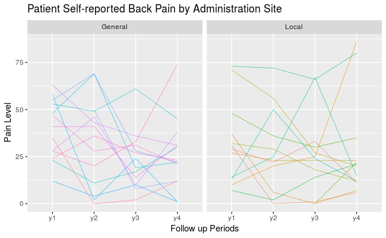

```r
 ggplot(data = df_long, aes(x = period , y = pain, group = id)) +
  geom_line(aes(colour = id), size = 0.2) +
  facet_grid(. ~ site) +
  xlab("Follow up Periods") +
  ylab("Pain Level") +
  ggtitle("Patient Self-reported Back Pain by Administration Site") +
  theme(legend.position = "none")
```

### Step 5: Perform t-tests

Calculate the mean of self reported pain grouped by *site* and *subject*. We use the the pipe operator to simplify the code. Here x %>% f is equivalent to f(x) and x %>% f(y) is equivalent to f(x,y). Piping becomes really useful when you have multiple nested operationssuch as f(g(l(x))) where f, g, and l are functions.

```r
df_long_means <- df_long %>%
  group_by(site, id) %>%
  summarise(pain_avg = mean(pain,
                       na.rm = TRUE))
df_long_means
```

| site | id | pain_avg |
| --- | --- | --- |
| General | 14 | 20.250000 |
| General | 15 | 52.000000 |
| General | 16 | 39.500000 |
| General | 17 | 21.250000 |
| General | 18 | 6.750000 |
| General | 19 | 43.500000 |
| General | 20 | 23.333333 |
| General | 21 | 30.500000 |
| General | 22 | 43.250000 |
| General | 23 | 31.750000 |

[output cut: 17 more lines]

Although equal variance is not the default setting, we set *var.equal* to TRUE in order to reproduce the results in the class notes. The regression notation *“pain_avg~site”* should remind you that we working with a linear model.

```r
t.test(pain_avg~site,
       data = df_long_means,
       var.equal = TRUE)
```

```
    Two Sample t-test

data:  pain_avg by site
t = 0.49099, df = 25, p-value = 0.6277
alternative hypothesis: true difference in means is not equal to 0
95 percent confidence interval:
 -9.235788 15.017839
sample estimates:
mean in group General   mean in group Local
             30.16667              27.27564
```

We select the rows corresponding to the last period with the filter function.

```r
df_long_last <- df_long %>% filter(period == "y4")
df_long_last
```

| id | site | period | pain |
| --- | --- | --- | --- |
| 1 | Local | y4 | 11 |
| 2 | Local | y4 | 6 |
| 3 | Local | y4 | 86 |
| 4 | Local | y4 | 7 |
| 5 | Local | y4 | 23 |
| 6 | Local | y4 | 20 |
| 7 | Local | y4 | 12 |
| 8 | Local | y4 | 22 |
| 9 | Local | y4 | 35 |
| 10 | Local | y4 | 21 |

[output cut: 17 more lines]

We run a t-test with the filtered dataset

```r
t.test(pain~site,
       data = df_long_last,
       var.equal= TRUE)
```

```
    Two Sample t-test

data:  pain by site
t = -0.11432, df = 25, p-value = 0.9099
alternative hypothesis: true difference in means is not equal to 0
95 percent confidence interval:
 -18.91157  16.92256
sample estimates:
mean in group General   mean in group Local
             25.92857              26.92308
```

## Example 2

### Step 1: Load data

```r
BPRS_df_wide <- read.table("BPRS_data.txt",
                   header = TRUE,
                   na.strings = ".")
BPRS_df_wide
```

| group | id | w0 | w1 | w2 | w3 | w4 | w5 | w6 | w7 | w8 |
| --- | --- | --- | --- | --- | --- | --- | --- | --- | --- | --- |
| 1 | 1 | 42 | 39 | 36 | 43 | 41 | 40 | 38 | 47 | 41 |
| 1 | 2 | 58 | 68 | 61 | 55 | 43 | 34 | 28 | 28 | 28 |
| 1 | 3 | 54 | 55 | 41 | 38 | 43 | 28 | 29 | 25 | 24 |
| 1 | 4 | 55 | 77 | 49 | 54 | 56 | 50 | 47 | 42 | 46 |
| 1 | 5 | 72 | 75 | 72 | 65 | 50 | 39 | 32 | 38 | 32 |
| 1 | 6 | 48 | 43 | 41 | 38 | 36 | 29 | 33 | 27 | 25 |
| 1 | 7 | 71 | 61 | 47 | 30 | 27 | 40 | 30 | 31 | 31 |
| 1 | 8 | 30 | 36 | 38 | 38 | 31 | 26 | 26 | 25 | 24 |
| 1 | 9 | 41 | 43 | 39 | 35 | 28 | 22 | 20 | 23 | 21 |
| 1 | 10 | 57 | 51 | 51 | 55 | 53 | 43 | 43 | 39 | 32 |

[output cut: 30 more lines]

### Step 2: Trasform data format.

```r
BPRS_df_long <- gather(data = BPRS_df_wide ,
                         key = "week",
                         value = "score",
                         3:11)
# change type of variables into factors
BPRS_df_long  <- within(BPRS_df_long, {
  group <- factor(group, labels = c("Group 1", "Group 2"))
  id <- factor(id)
  week <- factor(week)
})
BPRS_df_long
```

| group | id | week | score |
| --- | --- | --- | --- |
| Group 1 | 1 | w0 | 42 |
| Group 1 | 2 | w0 | 58 |
| Group 1 | 3 | w0 | 54 |
| Group 1 | 4 | w0 | 55 |
| Group 1 | 5 | w0 | 72 |
| Group 1 | 6 | w0 | 48 |
| Group 1 | 7 | w0 | 71 |
| Group 1 | 8 | w0 | 30 |
| Group 1 | 9 | w0 | 41 |
| Group 1 | 10 | w0 | 57 |

[output cut: 350 more lines]

### Step 3: Plot data

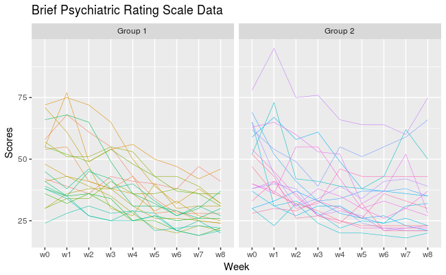

```r
ggplot(data = BPRS_df_long, aes(x = week , y = score, group = id)) +
  geom_line(aes(colour = id), size = 0.2) +
  facet_grid(  ~ group) +
  xlab("Week") +
  ylab("Scores") +
  ggtitle("Brief Psychiatric Rating Scale Data")  +
  theme(legend.position = "none")
```

We use facets to plot the data for each individual

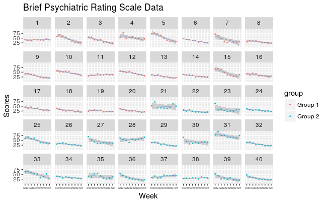

```r
ggplot(data = BPRS_df_long,
       aes(x = week ,
           y = score,
           group = group)) +
  geom_point(aes(colour = group),
            size = 0.4) +
  geom_smooth(method = 'lm', size = 0.1) +
  facet_wrap(  ~ id, ncol = 8) +
  xlab("Week") +
  ylab("Scores") +
  ggtitle("Brief Psychiatric Rating Scale Data")   +
  theme(axis.text.x = element_text(size = 4))
```

## Example 3

### Step 1: Load data

```r
depression_df_wide <- read.table("depression.txt",
                   header = TRUE,
                   na.strings = ".")
depression_df_wide
```

| id | group | b1 | b2 | month1 | month2 | month3 | month4 |
| --- | --- | --- | --- | --- | --- | --- | --- |
| 1 | 1 | 11 | 12 | 11 | 12 | 15 | 18 |
| 2 | 1 | 5 | 6 | 7 | 8 | 7 | 9 |
| 3 | 1 | 11 | 8 | 8 | 9 | 10 | 13 |
| 4 | 1 | 10 | 8 | 10 | 8 | 12 | 12 |
| 6 | 1 | 7 | 7 | 10 | 8 | 9 | 11 |
| 7 | 1 | 5 | 5 | 7 | 5 | 6 | 7 |
| 8 | 1 | 7 | 7 | 7 | 8 | 9 | 11 |
| 9 | 1 | 10 | 11 | 13 | 11 | 14 | 17 |
| 10 | 1 | 3 | 2 | 2 | 4 | 3 | 5 |
| 11 | 1 | 7 | 7 | 8 | 9 | 10 | 10 |

[output cut: 26 more lines]

### Step 2a: Trasform data format

```r
depression_df_long_months <- gather(data = depression_df_wide ,
                         key = "period",
                         value = "score",
                         5:8)
# change type of variables into factors
depression_df_long_months  <- within(depression_df_long_months, {
  group <- factor(group)
  id <- factor(id)
  period <- factor(period)
})
depression_df_long_months
```

| id | group | b1 | b2 | period | score |
| --- | --- | --- | --- | --- | --- |
| 1 | 1 | 11 | 12 | month1 | 11 |
| 2 | 1 | 5 | 6 | month1 | 7 |
| 3 | 1 | 11 | 8 | month1 | 8 |
| 4 | 1 | 10 | 8 | month1 | 10 |
| 6 | 1 | 7 | 7 | month1 | 10 |
| 7 | 1 | 5 | 5 | month1 | 7 |
| 8 | 1 | 7 | 7 | month1 | 7 |
| 9 | 1 | 10 | 11 | month1 | 13 |
| 10 | 1 | 3 | 2 | month1 | 2 |
| 11 | 1 | 7 | 7 | month1 | 8 |

[output cut: 134 more lines]

### Step 3a: Perform a Single-Sample Repeated Measures Anova

The syntax *period*group* is equivalent to *period+ group + period:group* where *period:group* denotes an interaction. The Error term specifies which effects are seen within subjects (id). Here we specify a random effect of time periods inside subjects: Error(id/period). The “/period” can be omitted. The speficication for the Anova model is basically a randomized complete blocks design or more precisely a split-plot since the subjects in Group 1 and Group 2 are not the same

```r
fit1 <- aov( score ~ period*group + Error(id/period),
             data = depression_df_long_months)
summary(fit1)
```

```
Error: id
          Df Sum Sq Mean Sq F value Pr(>F)
group      1    212  211.98   5.124 0.0301 *
Residuals 34   1407   41.37
---
Signif. codes:  0 ‘***’ 0.001 ‘**’ 0.01 ‘*’ 0.05 ‘.’ 0.1 ‘ ’ 1

Error: id:period
              Df Sum Sq Mean Sq F value   Pr(>F)
period         3  84.06  28.019  14.911 4.04e-08 ***
period:group   3  42.29  14.095   7.501 0.000138 ***
Residuals    102 191.66   1.879
---
Signif. codes:  0 ‘***’ 0.001 ‘**’ 0.01 ‘*’ 0.05 ‘.’ 0.1 ‘ ’ 1
```

### Step 2b: Trasform data format

We now need to collapse the two baseline variables into a single column

```r
depression_df_long_baseline <- gather(data = depression_df_wide ,
                         key = "baseline",
                         value = "score",
                         3:4)
# change type of variables into factors
depression_df_long_baseline  <- within(depression_df_long_baseline, {
  group <- factor(group)
  id <- factor(id)
  baseline <- factor(baseline)
})
depression_df_long_baseline
```

| id | group | month1 | month2 | month3 | month4 | baseline | score |
| --- | --- | --- | --- | --- | --- | --- | --- |
| 1 | 1 | 11 | 12 | 15 | 18 | b1 | 11 |
| 2 | 1 | 7 | 8 | 7 | 9 | b1 | 5 |
| 3 | 1 | 8 | 9 | 10 | 13 | b1 | 11 |
| 4 | 1 | 10 | 8 | 12 | 12 | b1 | 10 |
| 6 | 1 | 10 | 8 | 9 | 11 | b1 | 7 |
| 7 | 1 | 7 | 5 | 6 | 7 | b1 | 5 |
| 8 | 1 | 7 | 8 | 9 | 11 | b1 | 7 |
| 9 | 1 | 13 | 11 | 14 | 17 | b1 | 10 |
| 10 | 1 | 2 | 4 | 3 | 5 | b1 | 3 |
| 11 | 1 | 8 | 9 | 10 | 10 | b1 | 7 |

[output cut: 62 more lines]

### Step 3b: Perform a Single-Sample Repeated Measures Anova ()

Here we fit the randomized blocks Anova. The group is a fixed effect. The baseline measurements are nested within subjects.

```r
fit2 <- aov( score ~ baseline*group + Error(id/baseline),
             data = depression_df_long_baseline)
summary(fit2)
```

```
Error: id
          Df Sum Sq Mean Sq F value Pr(>F)
group      1   47.7   47.68   3.488 0.0704 .
Residuals 34  464.7   13.67
---
Signif. codes:  0 ‘***’ 0.001 ‘**’ 0.01 ‘*’ 0.05 ‘.’ 0.1 ‘ ’ 1

Error: id:baseline
               Df Sum Sq Mean Sq F value Pr(>F)
baseline        1   0.01  0.0139   0.011  0.916
baseline:group  1   1.67  1.6688   1.357  0.252
Residuals      34  41.82  1.2299
```